# TP - Analyse du dataset Titanic

2026-11-12

# 1. Chargement des packages et des données

`install.packages("carData")`

`install.packages("ggplot2")`

`install.packages("dplyr")`

```r
library(carData)
library(ggplot2)
library(dplyr)

data("TitanicSurvival")
```

## 1.2 Présentation du jeu de données

```r
head(TitanicSurvival)
```

```
##                                 survived    sex     age passengerClass
## Allen, Miss. Elisabeth Walton        yes female 29.0000            1st
## Allison, Master. Hudson Trevor       yes   male  0.9167            1st
## Allison, Miss. Helen Loraine          no female  2.0000            1st
## Allison, Mr. Hudson Joshua Crei       no   male 30.0000            1st
## Allison, Mrs. Hudson J C (Bessi       no female 25.0000            1st
## Anderson, Mr. Harry                  yes   male 48.0000            1st
```

Le jeu de données contient des informations sur les passagers du Titanic. Les instructions suivantes permettent d’examiner sa structure et le contenu de ses variables.

```r
str(TitanicSurvival)
```

```
## 'data.frame':    1309 obs. of  4 variables:
##  $ survived      : Factor w/ 2 levels "no","yes": 2 2 1 1 1 2 2 1 2 1 ...
##  $ sex           : Factor w/ 2 levels "female","male": 1 2 1 2 1 2 1 2 1 2 ...
##  $ age           : num  29 0.917 2 30 25 ...
##  $ passengerClass: Factor w/ 3 levels "1st","2nd","3rd": 1 1 1 1 1 1 1 1 1 1 ...
```

```r
summary(TitanicSurvival)
```

```
##  survived      sex           age          passengerClass
##  no :809   female:466   Min.   : 0.1667   1st:323
##  yes:500   male  :843   1st Qu.:21.0000   2nd:277
##                         Median :28.0000   3rd:709
##                         Mean   :29.8811
##                         3rd Qu.:39.0000
##                         Max.   :80.0000
##                         NAs    :263
```

## 1.3 Statistiques descriptives

Nombre de passagers étudiés :

```r
nrow(TitanicSurvival)
```

```
## [1] 1309
```

Répartition des passagers selon leur survie :

```r
table(TitanicSurvival$survived, useNA = "ifany")
```

```
##
##  no yes
## 809 500
```

Répartition selon le sexe :

```r
table(TitanicSurvival$sex, useNA = "ifany")
```

```
##
## female   male
##    466    843
```

Répartition selon la classe :

```r
table(TitanicSurvival$passengerClass, useNA = "ifany")
```

```
##
## 1st 2nd 3rd
## 323 277 709
```

Âge des passagers :

```r
summary(TitanicSurvival$age)
```

```
##    Min. 1st Qu.  Median    Mean 3rd Qu.    Max.     NAs
##  0.1667 21.0000 28.0000 29.8811 39.0000 80.0000     263
```

# 2. Analyse graphique

## 2.1 Répartition de la survie en fonction du sexe

Le graphique suivant compare le nombre de survivants et de non-survivants pour chaque sexe.

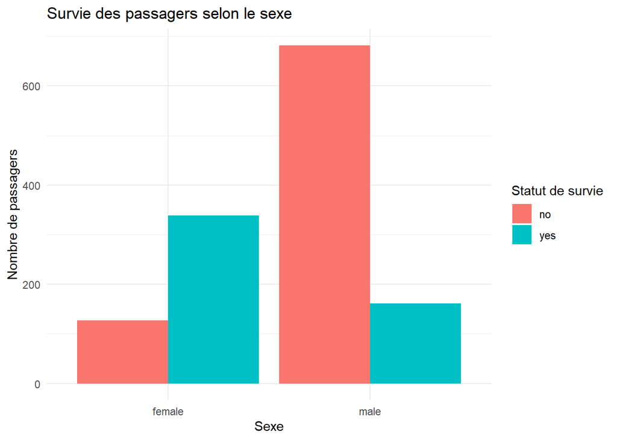

```r
ggplot(
  TitanicSurvival,
  aes(x = sex, fill = survived)
) +
  geom_bar(position = "dodge") +
  labs(
    title = "Survie des passagers selon le sexe",
    x = "Sexe",
    y = "Nombre de passagers",
    fill = "Statut de survie"
  ) +
  theme_minimal()
```

**Interprétation :** Être une femme augmentait considérablement les chances de survie lors de ce naufrage, tandis qu’être un homme diminuait drastiquement ces chances.

## 2.2 Répartition de la survie en fonction de la classe

Ce graphique compare le nombre de survivants et de non-survivants dans chaque classe de passagers.

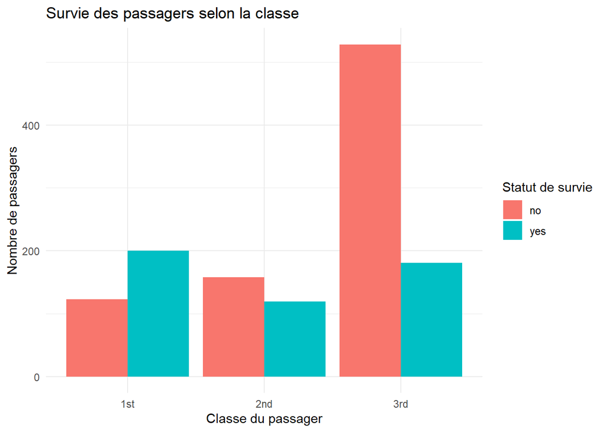

```r
ggplot(
  TitanicSurvival,
  aes(x = passengerClass, fill = survived)
) +
  geom_bar(position = "dodge") +
  labs(
    title = "Survie des passagers selon la classe",
    x = "Classe du passager",
    y = "Nombre de passagers",
    fill = "Statut de survie"
  ) +
  theme_minimal()
```

**Interprétation :** Plus la classe était élevée, plus les chances de survie étaient grandes. Le graphique montre une inégalité flagrante face à la mort lors du naufrage.

## 2.3 Âge des passagers en fonction de la survie

Le diagramme en boîte permet de comparer la distribution de l’âge entre les passagers ayant survécu et ceux qui n’ont pas survécu. Les valeurs d’âge manquantes sont ignorées pour ce graphique.

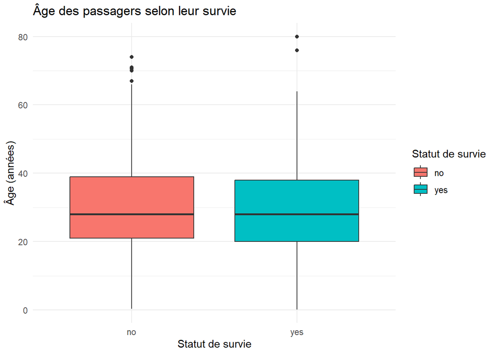

```r
ggplot(
  TitanicSurvival,
  aes(x = survived, y = age, fill = survived)
) +
  geom_boxplot(na.rm = TRUE) +
  labs(
    title = "Âge des passagers selon leur survie",
    x = "Statut de survie",
    y = "Âge (années)",
    fill = "Statut de survie"
  ) +
  theme_minimal()
```

**Interprétation :** Ce graphique montre que, globalement, les personnes qui ont survécu et celles qui sont décédées avaient des profils d’âge très similaires (majoritairement de jeunes adultes). L’âge n’est pas le facteur qui explique le mieux la survie dans cette représentation globale.

# 3. Conclusion

Les données démontrent statistiquement que le sexe et la classe sociale ont été des facteurs discriminants majeurs pour la survie lors de ce naufrage. L’âge, en revanche, n’apparaît pas comme un facteur isolé déterminant dans cette vue globale. Les explications de ces disparités relèvent du protocole d’évacuation maritime et des inégalités structurelles de la société de l’époque, qui ne sont pas “écrits” dans les graphiques mais les sous-tendent.

# 4. Création d’un package R avec des fonctions d’analyse

```r
library(carData)
library(TitanicPckg)

data("TitanicSurvival")
taux_survie(TitanicSurvival, "sex")
```

```
##        modalite taux_survie
## female   female    72.74678
## male       male    19.09846
```

```r
taux_survie(TitanicSurvival, "passengerClass")
```

```
##     modalite taux_survie
## 1st      1st    61.91950
## 2nd      2nd    42.96029
## 3rd      3rd    25.52891
```